# Homework 2 - Sampling Variability

Engineering Statistics I (MA223)

## Problem 1 (Beer Fraud)

In February 2013, two California residents filed a class-action lawsuit against Anheuser-Busch, alleging the company was watering down beers to boost profits. They argued that because water was being added, the true alcohol content of the beer by volume is less than the advertised amount of 5%.

Suppose, for the purposes of this question, they measured the alcohol content of the beer by volume for a random sample of 24 cans. For these 24 cans, they found the average alcohol content to be 4.95%.

### Part (a)

What is the **parameter** of interest for this study?

### Part (b)

State the null and alternative hypotheses that capture the question of interest for the plaintiffs. Note: the plaintiffs (the California residents) are the ones conducting the study; so, think about what they want to show.

### Part (c)

The figure below represents a model for the sampling distribution of the sample mean alcohol content by volume (%) for a sample of 24 cans. Based on this graphic, do the plaintiffs have evidence to support their case? Explain.

Note: you need not understand the code; simply run it to construct the graphic.

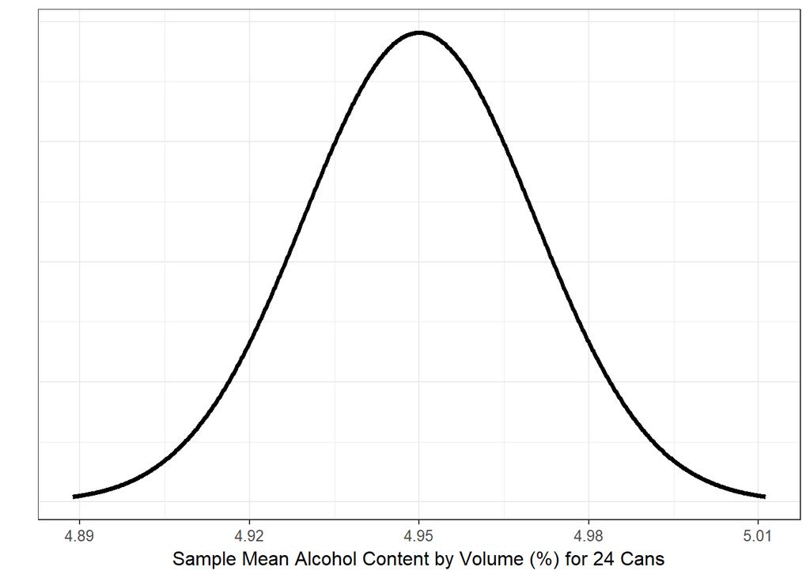

Model of the sampling distribution of the sample mean.

### Part (d)

Using the plot provided in the part (c), which of the following intervals *most likely* represents the 95% confidence interval?

1. (4.94, 4.96)
2. (4.93, 4.97)
3. (4.91, 4.99)
4. (4.05, 5.90)

No justification required.

### Part (e)

The lawyer for the plaintiffs examines their results and states “This is fantastic! We have rougly a 99% chance that the Anheuser-Busch is underfilling beer cans, on average. This case is a slam dunk.” Is this statement appropriate? Explain.

## Problem 2 (Faculty Salaries)

With any luck, by the time you are working on this assignment, I will have been promoted from an Assistant Professor to the rank of Associate Professor. I would like to estimate how much I should expect my pay to increase, on average, as a result of the promotion. Unfortunately, salaries for Rose-Hulman faculty are not publicly available. However, a study was done during the 2008-2009 academic year in which faculty from across the nation were surveyed regarding salaries. We want to use this sample to address my question of interest.

The data is available in R automatically (`Salaries`). The first few records of the data are shown below.

```
       rank discipline yrs.since.phd yrs.service  sex salary
1      Prof          B            19          18 Male 139750
2      Prof          B            20          16 Male 173200
3  AsstProf          B             4           3 Male  79750
4      Prof          B            45          39 Male 115000
5      Prof          B            40          41 Male 141500
6 AssocProf          B             6           6 Male  97000
```

## Part (a)

Construct a side-by-side boxplot comparing the salaries for assistant professors and those for associate professors. In order to make this plot, we need to perform some data manipulation. Perform the following steps first:

1. “Filter” out the records corresponding to full professors (`rank!="Prof"`) to keep only those records of interest for this particular question.
2. Be sure to store the resulting data in a new dataset (called `Salaries.reduced` for example).
3. Recode the ranks to be more legible (specifically, change “AsstProf” to “Assistant Professor” and change “AssocProf” to “Associate Professor”); this can be done by “mutating” the dataset and “recoding” the variable of interest (see the Coding Cookbook for additional tips on recoding).

Once you have cleaned the data, you can construct the graphic. Note: be sure to appropriately label the x- and y-axes.

## Part (b)

Below is a model for the sampling distribution of the difference in the average salaries between associate and assistant professors based on the sample (associate minus assistant). Based on the figure, what are reasonable values for the increase in salary, on average, for associate professors compared to assistant professors? Explain.

Note: you need not know how the code works.

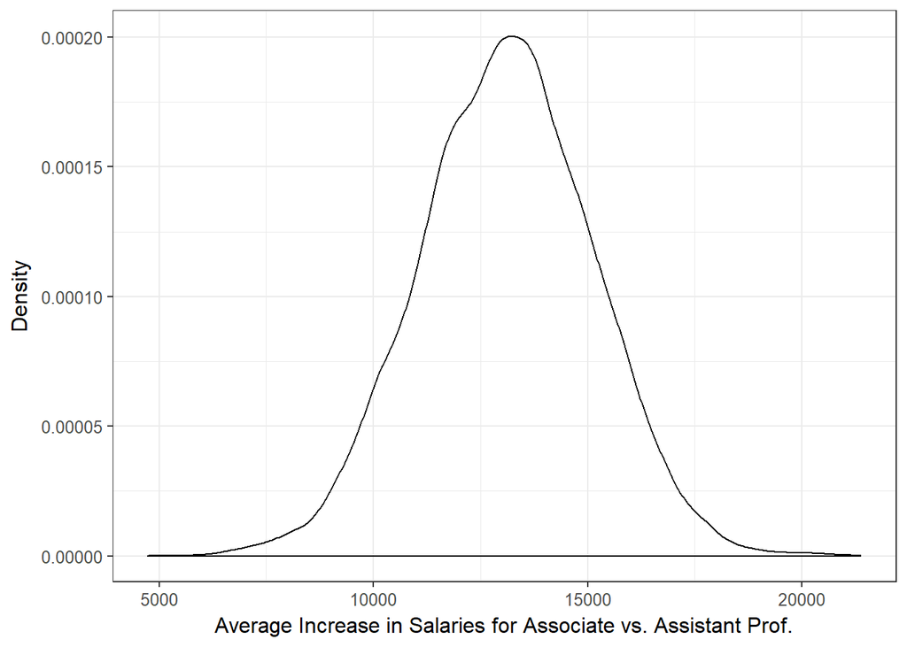

Model of the sampling distribution of the difference in the average salaries of associate and assistant professors.

### Part (c)

Based on the figure in part (b), which of the following is most likely a 99% CI for the average difference in salary for associate compared to assistant professors?

A. (5136, 21136) B. (8136, 18136) C. (10636, 15636) D. (12636, 13636)

No justification required.

### Part (d)

The 90% CI for the average difference in the salary of associate professors compared with assistant professors is (9952, 16164). Which of the following interpretations of this interval is correct?

A. There is a 90% chance that a professor who is promoted to associate will see a salary increase between $9952 and $16164. B. 90% of professors who are promoted to associate had an increased salary between $9952 and $16164. C. There is a 90% chance that the average salary difference between all associate and all assistant professors is between $9952 and $16164. D. None of the above.

No explanation required.

### Part (e)

Give one reason that I should not conclude that I can expect a salary increase between $9952 and $16164 if I am promoted to associate professor this year? Explain.